# Multi-class Classification

## Project Topic:

#### Estimation of Obesity Levels Based On Eating Habits and Physical Condition

This dataset include data for the estimation of obesity levels in individuals from the countries of Mexico, Peru and Colombia, based on their eating habits and physical condition. The data contains 17 attributes and 2111 records, the records are labeled with the class variable NObesity (Obesity Level), that allows classification of the data using the values of Insufficient Weight, Normal Weight, Overweight Level I, Overweight Level II, Obesity Type I, Obesity Type II and Obesity Type III.

This project is aimed at predicting obesity levels in individuals from Mexico, Peru, and Colombia based on their eating habits and physical conditions by developing and depoying a Machine Learning model.

**Link to data**: https://archive.ics.uci.edu/dataset/544/estimation+of+obesity+levels+based+on+eating+habits+and+physical+condition

```python
import pandas as pd
import numpy as np
import matplotlib.pyplot as plt
import seaborn as sns
from sklearn.model_selection import train_test_split
from sklearn.preprocessing import OneHotEncoder, StandardScaler
from sklearn.linear_model import LogisticRegression
from sklearn.multiclass import OneVsOneClassifier
from sklearn.metrics import accuracy_score
```

The attributes of the dataset are descibed below:

| Variable Name | Type | Description |
| --- | --- | --- |
| Gender | Categorical |  |
| Age | Continuous |  |
| Height | Continuous |  |
| Weight | Continuous |  |
| family_history_with_overweight | Binary | Has a family member suffered or suffers from overweight? |
| FAVC | Binary | Do you eat high caloric food frequently? |
| FCVC | Integer | Do you usually eat vegetables in your meals? |
| NCP | Continuous | How many main meals do you have daily? |
| CAEC | Categorical | Do you eat any food between meals? |
| SMOKE | Binary | Do you smoke? |
| CH2O | Continuous | How much water do you drink daily? |
| SCC | Binary | Do you monitor the calories you eat daily? |
| FAF | Continuous | How often do you have physical activity? |
| TUE | Integer | How much time do you use technological devices such as cell phone, videogames, television, computer and others? |
| CALC | Categorical | How often do you drink alcohol? |
| MTRANS | Categorical | Which transportation do you usually use? |
| NObeyesdad | Categorical | Obesity level |

```python
#Load data
data=pd.read_csv(r'C:\Users\Owner\OneDrive\Desktop\My Projects\ObesityDataSet_raw_and_data_sinthetic.csv')
data.sample(5)
```

|  | Gender | Age | Height | Weight | family_history_with_overweight | FAVC | FCVC | NCP | CAEC | SMOKE | CH2O | SCC | FAF | TUE | CALC | MTRANS | NObeyesdad |
| --- | --- | --- | --- | --- | --- | --- | --- | --- | --- | --- | --- | --- | --- | --- | --- | --- | --- |
| 691 | Male | 18.000000 | 1.786758 | 51.524444 | no | yes | 2.915480 | 3.0 | Sometimes | no | 1.777486 | no | 1.077469 | 1.000000 | Sometimes | Public_Transportation | Insufficient_Weight |
| 17 | Female | 29.000000 | 1.530000 | 78.000000 | no | yes | 2.000000 | 1.0 | Sometimes | no | 2.000000 | no | 0.000000 | 0.000000 | no | Automobile | Obesity_Type_I |
| 876 | Female | 16.093234 | 1.608914 | 65.000000 | yes | yes | 1.321028 | 1.0 | Sometimes | no | 2.000000 | yes | 0.371452 | 0.965604 | no | Public_Transportation | Overweight_Level_I |
| 351 | Female | 26.000000 | 1.650000 | 60.000000 | no | no | 3.000000 | 4.0 | Always | no | 2.000000 | no | 2.000000 | 0.000000 | no | Walking | Normal_Weight |
| 205 | Female | 23.000000 | 1.600000 | 78.000000 | yes | yes | 2.000000 | 1.0 | Sometimes | yes | 2.000000 | no | 1.000000 | 0.000000 | Frequently | Public_Transportation | Obesity_Type_I |

### Eploratory Data Analysis (EDA)

```python
data.isnull().sum()
```

```
Gender                            0
Age                               0
Height                            0
Weight                            0
family_history_with_overweight    0
FAVC                              0
FCVC                              0
NCP                               0
CAEC                              0
SMOKE                             0
CH2O                              0
SCC                               0
FAF                               0
TUE                               0
CALC                              0
MTRANS                            0
NObeyesdad                        0
dtype: int64
```

```python
data.shape
```

```
(2111, 17)
```

```python
data.nunique()
```

```
Gender                               2
Age                               1402
Height                            1574
Weight                            1525
family_history_with_overweight       2
FAVC                                 2
FCVC                               810
NCP                                635
CAEC                                 4
SMOKE                                2
CH2O                              1268
SCC                                  2
FAF                               1190
TUE                               1129
CALC                                 4
MTRANS                               5
NObeyesdad                           7
dtype: int64
```

```python
data.describe()
```

|  | Age | Height | Weight | FCVC | NCP | CH2O | FAF | TUE |
| --- | --- | --- | --- | --- | --- | --- | --- | --- |
| count | 2111.000000 | 2111.000000 | 2111.000000 | 2111.000000 | 2111.000000 | 2111.000000 | 2111.000000 | 2111.000000 |
| mean | 24.312600 | 1.701677 | 86.586058 | 2.419043 | 2.685628 | 2.008011 | 1.010298 | 0.657866 |
| std | 6.345968 | 0.093305 | 26.191172 | 0.533927 | 0.778039 | 0.612953 | 0.850592 | 0.608927 |
| min | 14.000000 | 1.450000 | 39.000000 | 1.000000 | 1.000000 | 1.000000 | 0.000000 | 0.000000 |
| 25% | 19.947192 | 1.630000 | 65.473343 | 2.000000 | 2.658738 | 1.584812 | 0.124505 | 0.000000 |
| 50% | 22.777890 | 1.700499 | 83.000000 | 2.385502 | 3.000000 | 2.000000 | 1.000000 | 0.625350 |
| 75% | 26.000000 | 1.768464 | 107.430682 | 3.000000 | 3.000000 | 2.477420 | 1.666678 | 1.000000 |
| max | 61.000000 | 1.980000 | 173.000000 | 3.000000 | 4.000000 | 3.000000 | 3.000000 | 2.000000 |

Visualize the distribution of the target variable to understand the class balance

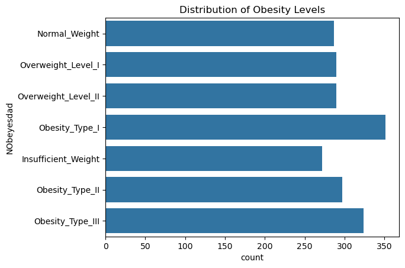

```python
# Distribution of target variable
%matplotlib inline
sns.countplot(y='NObeyesdad', data=data)
plt.title('Distribution of Obesity Levels')
plt.show()
```

This shows that the dataset is fairly balanced and does not require any special attention in terms of biased training.

### Data Preprocessing

#### Feature scaling

```python
# Standardizing continuous numerical features
continuous_columns = data.select_dtypes(include=['float64']).columns.tolist()

scaler = StandardScaler()
scaled_features = scaler.fit_transform(data[continuous_columns])

# Converting to a DataFrame
scaled_df = pd.DataFrame(scaled_features, columns=scaler.get_feature_names_out(continuous_columns))

# Combining with the original dataset
scaled_data = pd.concat([data.drop(columns=continuous_columns), scaled_df], axis=1)
```

```python
scaled_data.head()
```

|  | Gender | family_history_with_overweight | FAVC | CAEC | SMOKE | SCC | CALC | MTRANS | NObeyesdad | Age | Height | Weight | FCVC | NCP | CH2O | FAF | TUE |
| --- | --- | --- | --- | --- | --- | --- | --- | --- | --- | --- | --- | --- | --- | --- | --- | --- | --- |
| 0 | Female | yes | no | Sometimes | no | no | no | Public_Transportation | Normal_Weight | -0.522124 | -0.875589 | -0.862558 | -0.785019 | 0.404153 | -0.013073 | -1.188039 | 0.561997 |
| 1 | Female | yes | no | Sometimes | yes | yes | Sometimes | Public_Transportation | Normal_Weight | -0.522124 | -1.947599 | -1.168077 | 1.088342 | 0.404153 | 1.618759 | 2.339750 | -1.080625 |
| 2 | Male | yes | no | Sometimes | no | no | Frequently | Public_Transportation | Normal_Weight | -0.206889 | 1.054029 | -0.366090 | -0.785019 | 0.404153 | -0.013073 | 1.163820 | 0.561997 |
| 3 | Male | no | no | Sometimes | no | no | Frequently | Walking | Overweight_Level_I | 0.423582 | 1.054029 | 0.015808 | 1.088342 | 0.404153 | -0.013073 | 1.163820 | -1.080625 |
| 4 | Male | no | no | Sometimes | no | no | Sometimes | Public_Transportation | Overweight_Level_II | -0.364507 | 0.839627 | 0.122740 | -0.785019 | -2.167023 | -0.013073 | -1.188039 | -1.080625 |

### One-hot encoding

```python
# Identifying categorical columns
categorical_columns = scaled_data.select_dtypes(include=['object']).columns.tolist()
categorical_columns.remove('NObeyesdad')  # Exclude target column

# Applying one-hot encoding
encoder = OneHotEncoder(sparse_output=False, drop='first')
encoded_features = encoder.fit_transform(scaled_data[categorical_columns])

# Converting to a DataFrame
encoded_df = pd.DataFrame(encoded_features, columns=encoder.get_feature_names_out(categorical_columns))

# Combining with the original dataset
prepped_data = pd.concat([scaled_data.drop(columns=categorical_columns), encoded_df], axis=1)
```

```python
prepped_data.sample(6)
```

|  | NObeyesdad | Age | Height | Weight | FCVC | NCP | CH2O | FAF | TUE | Gender_Male | ... | CAEC_no | SMOKE_yes | SCC_yes | CALC_Frequently | CALC_Sometimes | CALC_no | MTRANS_Bike | MTRANS_Motorbike | MTRANS_Public_Transportation | MTRANS_Walking |
| --- | --- | --- | --- | --- | --- | --- | --- | --- | --- | --- | --- | --- | --- | --- | --- | --- | --- | --- | --- | --- | --- |
| 631 | Insufficient_Weight | -0.794397 | 0.128562 | -1.397216 | -2.647930 | 1.689740 | -1.644905 | 0.792176 | 0.077387 | 0.0 | ... | 0.0 | 0.0 | 0.0 | 0.0 | 1.0 | 0.0 | 0.0 | 0.0 | 1.0 | 0.0 |
| 1068 | Overweight_Level_II | -0.410348 | -0.464013 | -0.251521 | -0.785019 | 0.404153 | -0.013073 | 2.268880 | 1.699162 | 1.0 | ... | 0.0 | 0.0 | 0.0 | 0.0 | 0.0 | 1.0 | 0.0 | 0.0 | 1.0 | 0.0 |
| 1308 | Obesity_Type_I | -0.206889 | 0.364287 | 0.261339 | -0.785019 | 0.404153 | -1.238078 | -0.043313 | 0.561997 | 1.0 | ... | 0.0 | 0.0 | 0.0 | 0.0 | 0.0 | 1.0 | 0.0 | 0.0 | 1.0 | 0.0 |
| 1516 | Obesity_Type_II | 1.323209 | -0.067862 | 0.619617 | 0.704464 | -0.714426 | -1.644905 | 1.151257 | -1.080625 | 1.0 | ... | 0.0 | 0.0 | 0.0 | 0.0 | 0.0 | 1.0 | 0.0 | 0.0 | 1.0 | 0.0 |
| 904 | Overweight_Level_I | -0.638458 | 1.134837 | -0.048499 | -0.785019 | 0.404153 | -0.065274 | 0.073336 | 0.195295 | 1.0 | ... | 0.0 | 0.0 | 0.0 | 0.0 | 1.0 | 0.0 | 0.0 | 0.0 | 1.0 | 0.0 |
| 495 | Normal_Weight | -0.837360 | 1.054029 | -1.015318 | 1.088342 | -2.167023 | -1.644905 | -1.188039 | -1.080625 | 1.0 | ... | 0.0 | 0.0 | 1.0 | 0.0 | 0.0 | 1.0 | 0.0 | 1.0 | 0.0 | 0.0 |

6 rows × 24 columns

### Encoding the target variable

```python
# Encoding the target variable
prepped_data['NObeyesdad'] = prepped_data['NObeyesdad'].astype('category').cat.codes
prepped_data.head(10)
```

|  | NObeyesdad | Age | Height | Weight | FCVC | NCP | CH2O | FAF | TUE | Gender_Male | ... | CAEC_no | SMOKE_yes | SCC_yes | CALC_Frequently | CALC_Sometimes | CALC_no | MTRANS_Bike | MTRANS_Motorbike | MTRANS_Public_Transportation | MTRANS_Walking |
| --- | --- | --- | --- | --- | --- | --- | --- | --- | --- | --- | --- | --- | --- | --- | --- | --- | --- | --- | --- | --- | --- |
| 0 | 1 | -0.522124 | -0.875589 | -0.862558 | -0.785019 | 0.404153 | -0.013073 | -1.188039 | 0.561997 | 0.0 | ... | 0.0 | 0.0 | 0.0 | 0.0 | 0.0 | 1.0 | 0.0 | 0.0 | 1.0 | 0.0 |
| 1 | 1 | -0.522124 | -1.947599 | -1.168077 | 1.088342 | 0.404153 | 1.618759 | 2.339750 | -1.080625 | 0.0 | ... | 0.0 | 1.0 | 1.0 | 0.0 | 1.0 | 0.0 | 0.0 | 0.0 | 1.0 | 0.0 |
| 2 | 1 | -0.206889 | 1.054029 | -0.366090 | -0.785019 | 0.404153 | -0.013073 | 1.163820 | 0.561997 | 1.0 | ... | 0.0 | 0.0 | 0.0 | 1.0 | 0.0 | 0.0 | 0.0 | 0.0 | 1.0 | 0.0 |
| 3 | 5 | 0.423582 | 1.054029 | 0.015808 | 1.088342 | 0.404153 | -0.013073 | 1.163820 | -1.080625 | 1.0 | ... | 0.0 | 0.0 | 0.0 | 1.0 | 0.0 | 0.0 | 0.0 | 0.0 | 0.0 | 1.0 |
| 4 | 6 | -0.364507 | 0.839627 | 0.122740 | -0.785019 | -2.167023 | -0.013073 | -1.188039 | -1.080625 | 1.0 | ... | 0.0 | 0.0 | 0.0 | 0.0 | 1.0 | 0.0 | 0.0 | 0.0 | 1.0 | 0.0 |
| 5 | 1 | 0.738817 | -0.875589 | -1.282647 | -0.785019 | 0.404153 | -0.013073 | -1.188039 | -1.080625 | 1.0 | ... | 0.0 | 0.0 | 0.0 | 0.0 | 1.0 | 0.0 | 0.0 | 0.0 | 0.0 | 0.0 |
| 6 | 1 | -0.206889 | -2.162001 | -1.206267 | 1.088342 | 0.404153 | -0.013073 | -0.012109 | -1.080625 | 0.0 | ... | 0.0 | 0.0 | 0.0 | 0.0 | 1.0 | 0.0 | 0.0 | 1.0 | 0.0 | 0.0 |
| 7 | 1 | -0.364507 | -0.661187 | -1.282647 | -0.785019 | 0.404153 | -0.013073 | 2.339750 | -1.080625 | 1.0 | ... | 0.0 | 0.0 | 0.0 | 0.0 | 1.0 | 0.0 | 0.0 | 0.0 | 1.0 | 0.0 |
| 8 | 1 | -0.049271 | 0.839627 | -0.862558 | 1.088342 | 0.404153 | -0.013073 | -0.012109 | 0.561997 | 1.0 | ... | 0.0 | 0.0 | 0.0 | 1.0 | 0.0 | 0.0 | 0.0 | 0.0 | 1.0 | 0.0 |
| 9 | 1 | -0.364507 | 0.196421 | -0.709799 | -0.785019 | 0.404153 | -0.013073 | -0.012109 | 0.561997 | 1.0 | ... | 0.0 | 0.0 | 0.0 | 0.0 | 0.0 | 1.0 | 0.0 | 0.0 | 1.0 | 0.0 |

10 rows × 24 columns

```python
#Confirm encoded target classes
prepped_data['NObeyesdad'].unique()
```

```
array([1, 5, 6, 2, 0, 3, 4], dtype=int8)
```

To evaluate the correlation (relationship) of the target variable with the input features, it will be convenient to create a correlation matrix of the input variables with the target variable.

```python
#compute the pairwise correlation matrix
corr_matrix=prepped_data.corr()
corr_matrix.head()
```

|  | NObeyesdad | Age | Height | Weight | FCVC | NCP | CH2O | FAF | TUE | Gender_Male | ... | CAEC_no | SMOKE_yes | SCC_yes | CALC_Frequently | CALC_Sometimes | CALC_no | MTRANS_Bike | MTRANS_Motorbike | MTRANS_Public_Transportation | MTRANS_Walking |
| --- | --- | --- | --- | --- | --- | --- | --- | --- | --- | --- | --- | --- | --- | --- | --- | --- | --- | --- | --- | --- | --- |
| NObeyesdad | 1.000000 | 0.236170 | 0.038986 | 0.387643 | 0.018522 | -0.092616 | 0.108868 | -0.129564 | -0.069448 | 0.024908 | ... | 0.066715 | -0.023256 | -0.050679 | 0.047318 | 0.114104 | -0.134716 | -0.017351 | -0.034293 | -0.003748 | -0.073823 |
| Age | 0.236170 | 1.000000 | -0.025958 | 0.202560 | 0.016291 | -0.043944 | -0.045304 | -0.144938 | -0.296931 | 0.048394 | ... | -0.061795 | 0.091987 | -0.116283 | 0.082566 | -0.012483 | -0.018803 | 0.003652 | 0.020286 | -0.554448 | -0.063064 |
| Height | 0.038986 | -0.025958 | 1.000000 | 0.463136 | -0.038121 | 0.243672 | 0.213376 | 0.294709 | 0.051912 | 0.618466 | ... | -0.095625 | 0.055499 | -0.133753 | 0.045518 | 0.107070 | -0.127828 | 0.028996 | -0.010471 | -0.089684 | 0.036951 |
| Weight | 0.387643 | 0.202560 | 0.463136 | 1.000000 | 0.216125 | 0.107469 | 0.200575 | -0.051436 | -0.071561 | 0.161668 | ... | -0.106260 | 0.025746 | -0.201906 | -0.041778 | 0.259599 | -0.249828 | -0.021745 | -0.037300 | 0.059332 | -0.100805 |
| FCVC | 0.018522 | 0.016291 | -0.038121 | 0.216125 | 1.000000 | 0.042216 | 0.068461 | 0.019939 | -0.101135 | -0.274505 | ... | -0.103902 | 0.014320 | 0.071852 | -0.018655 | 0.082804 | -0.077072 | -0.029843 | -0.007512 | 0.057966 | 0.013991 |

5 rows × 24 columns

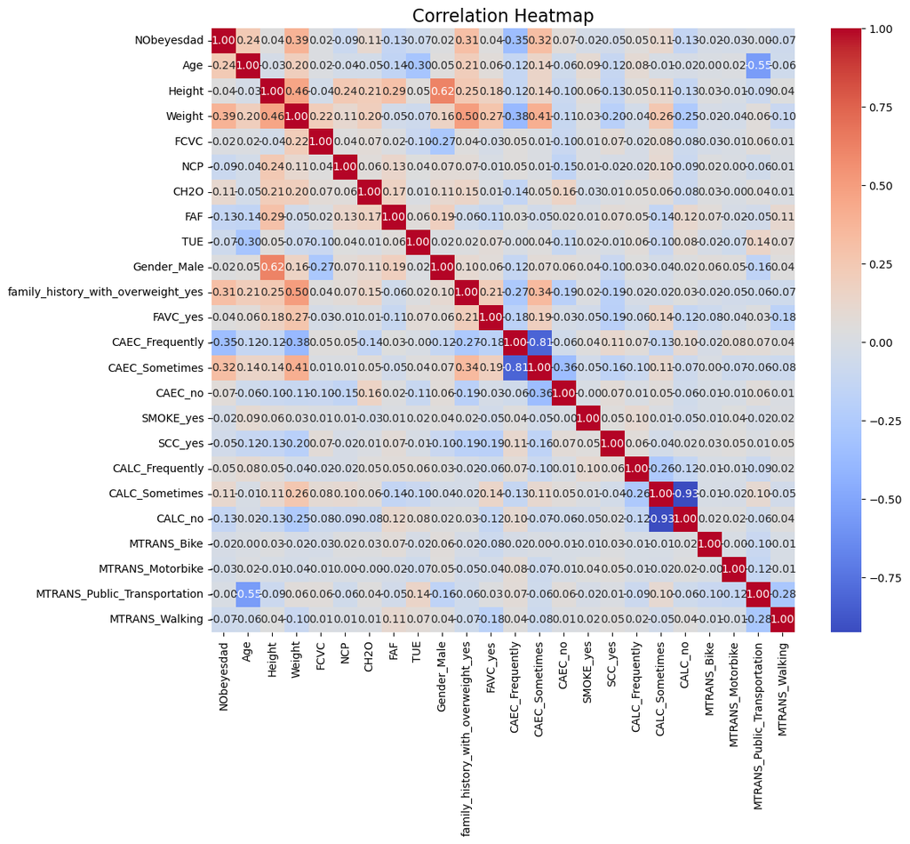

```python
#Produce the heatmap
plt.figure(figsize=(12, 10))
sns.heatmap(corr_matrix, annot=True, cmap='coolwarm', fmt=".2f")
plt.title("Correlation Heatmap", fontsize=16)
plt.show()
```

#### Split data into dependent(target) and independent(explanatory) variables.

```python
X=prepped_data.drop('NObeyesdad', axis=1)
y=prepped_data['NObeyesdad']
```

### Model training and evaluation

```python
# Training logistic regression model using One-vs-One
X_train,X_test,y_train, y_test=train_test_split(X,y, test_size=0.2, random_state=42)
model_ovo = OneVsOneClassifier(LogisticRegression(max_iter=1000))
model_ovo.fit(X_train, y_train)
```

```
OneVsOneClassifier(estimator=LogisticRegression(max_iter=1000))
```

```python
# Predictions
y_pred_ovo = model_ovo.predict(X_test)

# Evaluation metrics for OvO
print("One-vs-One (OvO) Strategy")
print(f"Accuracy: {np.round(100*accuracy_score(y_test, y_pred_ovo),2)}%")
```

```
One-vs-One (OvO) Strategy
Accuracy: 93.38%
```

```python
from sklearn.tree import DecisionTreeClassifier
```

```python
model = DecisionTreeClassifier(criterion="entropy", max_depth = 8)
model.fit(X_train, y_train)
```

```
DecisionTreeClassifier(criterion='entropy', max_depth=8)
```

```python
y_pred=model.predict(X_test)
```

```python
#Evaluate  model accuracy
print('Decision Tree method:')
print(f"model accuracy is: {round(model.score(X_test,y_test)*100,2)}%")
```

```
Decision Tree method:
model accuracy is: 94.33%
```

The two models seem to perform closely well. I decided to use the Decision tree because the algorithm captures non-linear relationships that may exist in the data. Also,the Decision tree can handle interactions automatically.

```python
%matplotlib inline
plt.figure(figsize=(6, 3))
sns.pairplot(prepped_data, hue='NObeyesdad')
plt.show()
```

[figure not shown]